# Practical Machine Learning - Course Project

## Preface

Given the training data provided by the [Weight Lifting Exercises Dataset](http://groupware.les.inf.puc-rio.br/har) we were asked to build a model to predict the outcome of twenty different test cases.

Extensive instructions are available on the [Coursera website](https://class.coursera.org/predmachlearn-013/human_grading/view/courses/973548/assessments/4/submissions).

## Basic setup

Prior to analyze our data we performed some setup operations:

- Loading libraries
- Setting a fixed seed for reproducibility
- Enabling multicore processing (optional, but highly recommended)

```r
library(caret)
library(doMC)

set.seed(56773)

registerDoMC(cores = 8)
```

## Loading the data

We assume that both the training and the testing data were previously made available in the current directory.

```r
data_train <- read.csv("pml-training.csv")
data_test <- read.csv("pml-testing.csv")
```

## Features extraction

First of all we looked at the data and removed all columns that weren’t predictors.

```r
data_train$X <- NULL
data_train$user_name <- NULL
data_train$raw_timestamp_part_1 <- NULL
data_train$raw_timestamp_part_2 <- NULL
data_train$cvtd_timestamp <- NULL
data_train$new_window <- NULL
data_train$num_window <- NULL
```

Then using the [caret::nearZeroVar](http://www.inside-r.org/packages/cran/caret/docs/nearZeroVar) function we searched for predictors with zero or near zero variance and removed them from our training set.

```r
nzv <- nearZeroVar(data_train)
data_train <- data_train[,-nzv]
```

By looking at the data we saw a lot of columns presenting missing values. Then we removed also those columns.

```r
data_train <- data_train[, !apply(data_train , 2, function(x) any(is.na(x)))]
```

After all these operations our selected features were as follows:

```r
str(data_train[,-53])
```

```
## 'data.frame':    19622 obs. of  52 variables:
##  $ roll_belt           : num  1.41 1.41 1.42 1.48 1.48 1.45 1.42 1.42 1.43 1.45 ...
##  $ pitch_belt          : num  8.07 8.07 8.07 8.05 8.07 8.06 8.09 8.13 8.16 8.17 ...
##  $ yaw_belt            : num  -94.4 -94.4 -94.4 -94.4 -94.4 -94.4 -94.4 -94.4 -94.4 -94.4 ...
##  $ total_accel_belt    : int  3 3 3 3 3 3 3 3 3 3 ...
##  $ gyros_belt_x        : num  0 0.02 0 0.02 0.02 0.02 0.02 0.02 0.02 0.03 ...
##  $ gyros_belt_y        : num  0 0 0 0 0.02 0 0 0 0 0 ...
##  $ gyros_belt_z        : num  -0.02 -0.02 -0.02 -0.03 -0.02 -0.02 -0.02 -0.02 -0.02 0 ...
##  $ accel_belt_x        : int  -21 -22 -20 -22 -21 -21 -22 -22 -20 -21 ...
##  $ accel_belt_y        : int  4 4 5 3 2 4 3 4 2 4 ...
##  $ accel_belt_z        : int  22 22 23 21 24 21 21 21 24 22 ...
##  $ magnet_belt_x       : int  -3 -7 -2 -6 -6 0 -4 -2 1 -3 ...
##  $ magnet_belt_y       : int  599 608 600 604 600 603 599 603 602 609 ...
##  $ magnet_belt_z       : int  -313 -311 -305 -310 -302 -312 -311 -313 -312 -308 ...
##  $ roll_arm            : num  -128 -128 -128 -128 -128 -128 -128 -128 -128 -128 ...
```

[output cut: 38 more lines]

## Subsetting into training and testing datasets

We splitted our data into two sets:

- 60% for model training
- 40% for model validation

```r
trainset <- createDataPartition(data_train$classe, p = 0.60, list = FALSE)
traindata <- data_train[trainset,]
testdata <- data_train[-trainset,]
```

## Model evaluation

We evaluated three different models, searching for the most accurate one:

- Classification Tree (`rpart`)
- Random Forest (`parRF`)
- Boosted Regression Model (`gbm`)

### Random Forest

```r
model_rf <- train(classe ~ ., method="parRF", data=traindata)
```

```r
# in-sample accuracy
prediction <- predict(model_rf, traindata)
cm <- confusionMatrix(prediction, traindata$classe)
print(cm$overall)
```

```
##       Accuracy          Kappa  AccuracyLower  AccuracyUpper   AccuracyNull
##      1.0000000      1.0000000      0.9996868      1.0000000      0.2843071
## AccuracyPValue  McnemarPValue
##      0.0000000            NaN
```

```r
# out-of-sample accuracy
prediction <- predict(model_rf, testdata)
cm <- confusionMatrix(prediction, testdata$classe)
print(cm$overall)
```

```
##       Accuracy          Kappa  AccuracyLower  AccuracyUpper   AccuracyNull
##      0.9932450      0.9914549      0.9911734      0.9949360      0.2844762
## AccuracyPValue  McnemarPValue
##      0.0000000            NaN
```

### Classification Tree

```r
model_rpart <- train(classe ~ ., method="rpart", data=traindata)
```

```r
# in-sample accuracy
prediction <- predict(model_rpart, traindata)
cm <- confusionMatrix(prediction, traindata$classe)
print(cm$overall)
```

```
##       Accuracy          Kappa  AccuracyLower  AccuracyUpper   AccuracyNull
##      0.4837806      0.3257283      0.4747172      0.4928520      0.2843071
## AccuracyPValue  McnemarPValue
##      0.0000000            NaN
```

```r
# out-of-sample accuracy
prediction <- predict(model_rpart, testdata)
cm <- confusionMatrix(prediction, testdata$classe)
print(cm$overall)
```

```
##       Accuracy          Kappa  AccuracyLower  AccuracyUpper   AccuracyNull
##   4.771858e-01   3.175222e-01   4.660803e-01   4.883083e-01   2.844762e-01
## AccuracyPValue  McnemarPValue
##  1.419523e-284            NaN
```

### Boosted Regression Model

```r
model_gbm <- train(classe ~ ., method="gbm", data=traindata, verbose=FALSE)
```

```r
# in-sample accuracy
prediction <- predict(model_gbm, traindata)
cm <- confusionMatrix(prediction, traindata$classe)
print(cm$overall)
```

```
##       Accuracy          Kappa  AccuracyLower  AccuracyUpper   AccuracyNull
##   9.757982e-01   9.693841e-01   9.728598e-01   9.784982e-01   2.843071e-01
## AccuracyPValue  McnemarPValue
##   0.000000e+00   2.837812e-10
```

```r
# out-of-sample accuracy
prediction <- predict(model_gbm, testdata)
cm <- confusionMatrix(prediction, testdata$classe)
print(cm$overall)
```

```
##       Accuracy          Kappa  AccuracyLower  AccuracyUpper   AccuracyNull
##   9.638032e-01   9.542143e-01   9.594306e-01   9.678267e-01   2.844762e-01
## AccuracyPValue  McnemarPValue
##   0.000000e+00   1.136466e-07
```

## Method choice

As we can see clearly in the following graph the Random Forest (`rf`) method reached the best accuracy overall.

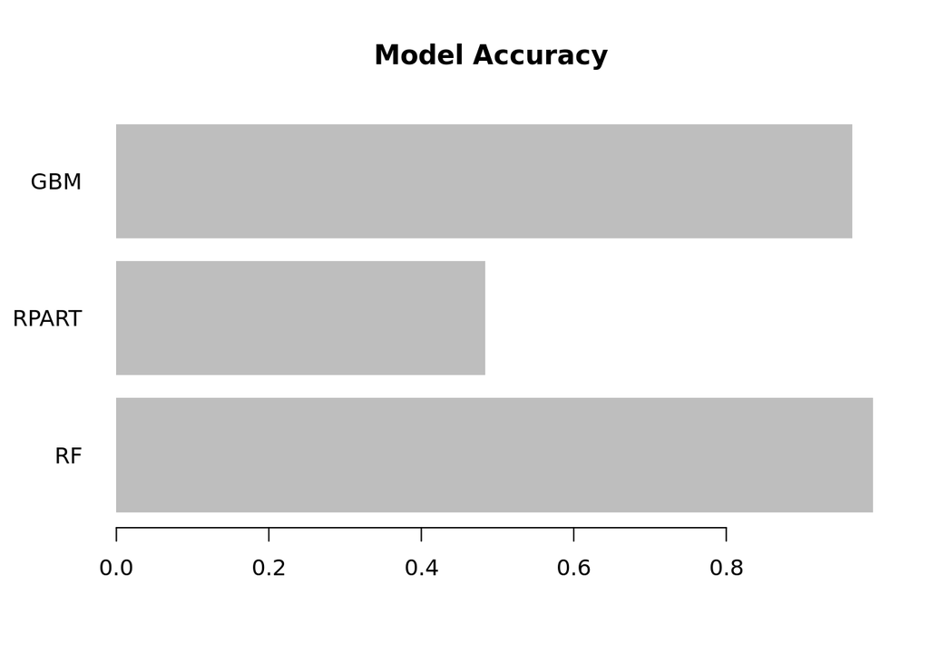

```r
model_accuracy <- matrix(c(0.9928626, 0.9907414, 0.9946041, 0.4837806, 0.4747172, 0.4928520, 9.652052e-01, 9.609098e-01, 9.691503e-01), ncol=3, byrow=TRUE)
colnames(model_accuracy) <- c("Mean", "Lower", "Upper")
rownames(model_accuracy) <- c("rf", "rpart", "gbm")
model_accuracy <- data.frame(model_accuracy)
barplot(model_accuracy$Mean, horiz=TRUE, las=1, border=NA, names.arg=c('RF', 'RPART', 'GBM'), cex.names=1, main="Model Accuracy")
```

## Predicting against our test dataset

```r
prediction <- predict(model_rf, data_test)
print(prediction)
```

```
##  [1] B A B A A E D B A A B C B A E E A B B B
## Levels: A B C D E
```